# Stroke dataset

Florencia Luque and Seyed Amirhossein Mosaddad

October 6, 2024

## Introduction

This dataset is a data obtain from *kaggle* and is used to predict if a pacient will probably get a stroke based on characteristic of them like gender, age, bmi, glucose levels.

The stroke variable have a 4.8% of people have had one. We want to check the distributions of the variables and possibles explanations of which variable can make an impact to get a stroke before creating a model to proved or been proved wrong about it.

The data have the follow variables:

1. id: unique identifier
2. gender: “Male”, “Female” or “Other”
3. age: age of the patient
4. hypertension: 0 if the patient doesn’t have hypertension, 1 if the patient has hypertension
5. heart_disease: 0 if the patient doesn’t have any heart diseases, 1 if the patient has a heart disease
6. ever_married: “No” or “Yes”
7. work_type: “children”, “Govt_jov”, “Never_worked”, “Private” or “Self-employed”
8. Residence_type: “Rural” or “Urban”
9. avg_glucose_level: average glucose level in blood
10. bmi: body mass index
11. smoking_status: “formerly smoked”, “never smoked”, “smokes” or “Unknown”*
12. stroke: 1 if the patient had a stroke or 0 if not

The next is a summary of the data.

```r
summary(data)
```

```
##        id           gender          age        hypertension heart_disease
##  Min.   :   67   Female:2994   Min.   : 0.08   0:4612       0:4834
##  1st Qu.:17741   Male  :2115   1st Qu.:25.00   1: 498       1: 276
##  Median :36932   Other :   1   Median :45.00
##  Mean   :36518                 Mean   :43.23
##  3rd Qu.:54682                 3rd Qu.:61.00
##  Max.   :72940                 Max.   :82.00
##
##  ever_married         work_type    Residence_type avg_glucose_level
##  No :1757     children     : 687   Rural:2514     Min.   : 55.12
##  Yes:3353     Govt_job     : 657   Urban:2596     1st Qu.: 77.25
##               Never_worked :  22                  Median : 91.89
##               Private      :2925                  Mean   :106.15
##               Self-employed: 819                  3rd Qu.:114.09
##                                                   Max.   :271.74
##
##       bmi                smoking_status stroke
##  Min.   :10.30   formerly smoked: 885   0:4861
##  1st Qu.:23.50   never smoked   :1892   1: 249
##  Median :28.10   smokes         : 789
##  Mean   :28.89   Unknown        :1544
##  3rd Qu.:33.10
##  Max.   :97.60
##  NA's   :201
```

### Dataset

We will star the analysis with the categorical variables.

## Categorical Variables

### Gender

This variable has 2 categories Male and Female (there’s one person who is Other but it’s only one so we can’t make any assumptions about this data).

The next table shows a summary of the quantity of people getting a stroke by gender and the corresponding percentage.

```r
stroke_gender = data %>% group_by(stroke,gender) %>% summarise(n = n(),.groups = "drop") %>% group_by(gender) %>% mutate(percent = n/sum(n)*100)

pander(stroke_gender)
```

| stroke | gender | n | percent |
| --- | --- | --- | --- |
| 0 | Female | 2853 | 95.29 |
| 0 | Male | 2007 | 94.89 |
| 0 | Other | 1 | 100 |
| 1 | Female | 141 | 4.709 |
| 1 | Male | 108 | 5.106 |

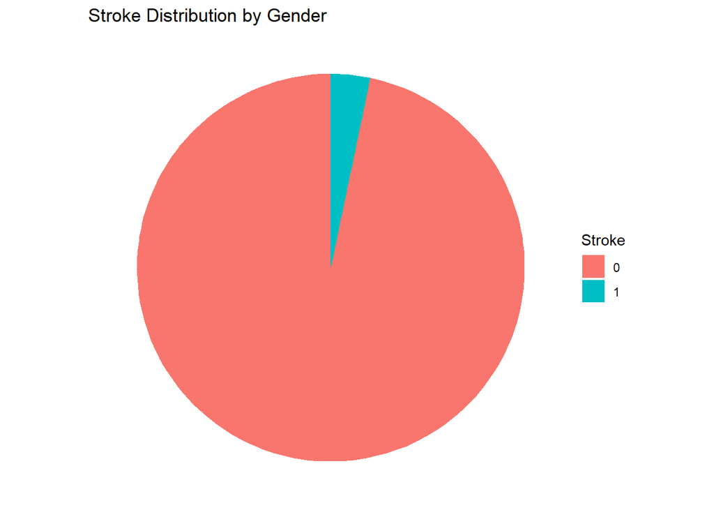

```r
ggplot(stroke_gender, aes(x = "", y = percent, fill = factor(stroke))) +
  geom_bar(stat = "identity", width = 1) +
  coord_polar(theta = "y") +
 # facet_wrap(~ gender) +  # Separate charts for each gender
  labs(title = "Stroke Distribution by Gender", fill = "Stroke", y = "Percentage") +
  theme_void()  # Remove x and y axes for pie chart aesthetic
```

As you can see there’s a higher % of male that have had a stroke in the data. This number is a little bit higher than the population so we don’t think this would have a great impact in the future model.

### Hypertension

```r
pander(data %>% group_by(stroke,hypertension) %>% summarise(n = n(),.groups = "drop")%>%
  group_by(stroke) %>% mutate(percent = n/sum(n)*100))
```

| stroke | hypertension | n | percent |
| --- | --- | --- | --- |
| 0 | 0 | 4429 | 91.11 |
| 0 | 1 | 432 | 8.887 |
| 1 | 0 | 183 | 73.49 |
| 1 | 1 | 66 | 26.51 |

### Heart disease

```r
pander(data %>% group_by(stroke,heart_disease) %>% summarise(n = n(),.groups = "drop")%>%
  group_by(heart_disease) %>% mutate(percent = n/sum(n)*100))
```

| stroke | heart_disease | n | percent |
| --- | --- | --- | --- |
| 0 | 0 | 4632 | 95.82 |
| 0 | 1 | 229 | 82.97 |
| 1 | 0 | 202 | 4.179 |
| 1 | 1 | 47 | 17.03 |

### Ever Married

```r
pander(data %>% group_by(stroke,ever_married) %>% summarise(n = n(),.groups = "drop")%>%
  group_by(ever_married) %>% mutate(percent = n/sum(n)*100))
```

| stroke | ever_married | n | percent |
| --- | --- | --- | --- |
| 0 | No | 1728 | 98.35 |
| 0 | Yes | 3133 | 93.44 |
| 1 | No | 29 | 1.651 |
| 1 | Yes | 220 | 6.561 |

### Work Type

```r
pander(data %>% group_by(stroke,work_type) %>% summarise(n = n(),.groups = "drop")%>%
  group_by(work_type) %>% mutate(percent = n/sum(n)*100))
```

| stroke | work_type | n | percent |
| --- | --- | --- | --- |
| 0 | children | 685 | 99.71 |
| 0 | Govt_job | 624 | 94.98 |
| 0 | Never_worked | 22 | 100 |
| 0 | Private | 2776 | 94.91 |
| 0 | Self-employed | 754 | 92.06 |
| 1 | children | 2 | 0.2911 |
| 1 | Govt_job | 33 | 5.023 |
| 1 | Private | 149 | 5.094 |
| 1 | Self-employed | 65 | 7.937 |

### Resident Type

```r
pander(data %>% group_by(stroke,Residence_type) %>% summarise(n = n(),.groups = "drop")%>%
  group_by(Residence_type) %>% mutate(percent = n/sum(n)*100))
```

| stroke | Residence_type | n | percent |
| --- | --- | --- | --- |
| 0 | Rural | 2400 | 95.47 |
| 0 | Urban | 2461 | 94.8 |
| 1 | Rural | 114 | 4.535 |
| 1 | Urban | 135 | 5.2 |

This could mean something

### Smoking Status

```r
pander(data %>% group_by(stroke,smoking_status) %>% summarise(n = n(),.groups = "drop")%>%
  group_by(smoking_status) %>% mutate(percent = n/sum(n)*100))
```

| stroke | smoking_status | n | percent |
| --- | --- | --- | --- |
| 0 | formerly smoked | 815 | 92.09 |
| 0 | never smoked | 1802 | 95.24 |
| 0 | smokes | 747 | 94.68 |
| 0 | Unknown | 1497 | 96.96 |
| 1 | formerly smoked | 70 | 7.91 |
| 1 | never smoked | 90 | 4.757 |
| 1 | smokes | 42 | 5.323 |
| 1 | Unknown | 47 | 3.044 |

### BMI

The first variable to evaluate will be the *bmi*. This variable is a metric that represent the relation between height and weight of a person. As you can see we have 3.9334638 % percentage of NA. However this is less than 5% so to treat this variable we will deleted all the rows with the NA in *bmi*

```r
summary(data$bmi)
```

```
##    Min. 1st Qu.  Median    Mean 3rd Qu.    Max.    NA's
##   10.30   23.50   28.10   28.89   33.10   97.60     201
```

Next, we will check the frecquency of the data using the cut between (0-18.5] as underweight, (18.5-24.9] as normal, (24.9-29.9] as overweight, (29.9-34.9] as obese and over this as extremely obese. This value leaves over 50% of our population in normal and overweight and almost 40% in the largest side in obese and extremely obese.

```r
data = na.omit(data)
frec_table <- cut(data$bmi, breaks = c(0, 18.5, 24.9, 29.9, 34.9, Inf),
                labels = c("Underweight", "Normal", "Overweight", "Obese", "Extremely Obese"))
data$cat_weight = frec_table

# Create frequency table
bmi_freq_table <- table(frec_table)
print(bmi_freq_table)
```

```
## frec_table
##     Underweight          Normal      Overweight           Obese Extremely Obese
##             349            1231            1409            1000             920
```

```r
bmi_rel_freq <- prop.table(bmi_freq_table)*100
print(bmi_rel_freq)
```

```
## frec_table
##     Underweight          Normal      Overweight           Obese Extremely Obese
##        7.109391       25.076390       28.702383       20.370748       18.741088
```

If we check this with a graph we can see that the graph looks a bit symetrical with an inclination to the right. This could it mean that the distribution is not a normal like could it seem. We are going to check the kurtosis and skewness shape to check if there´s a problem.

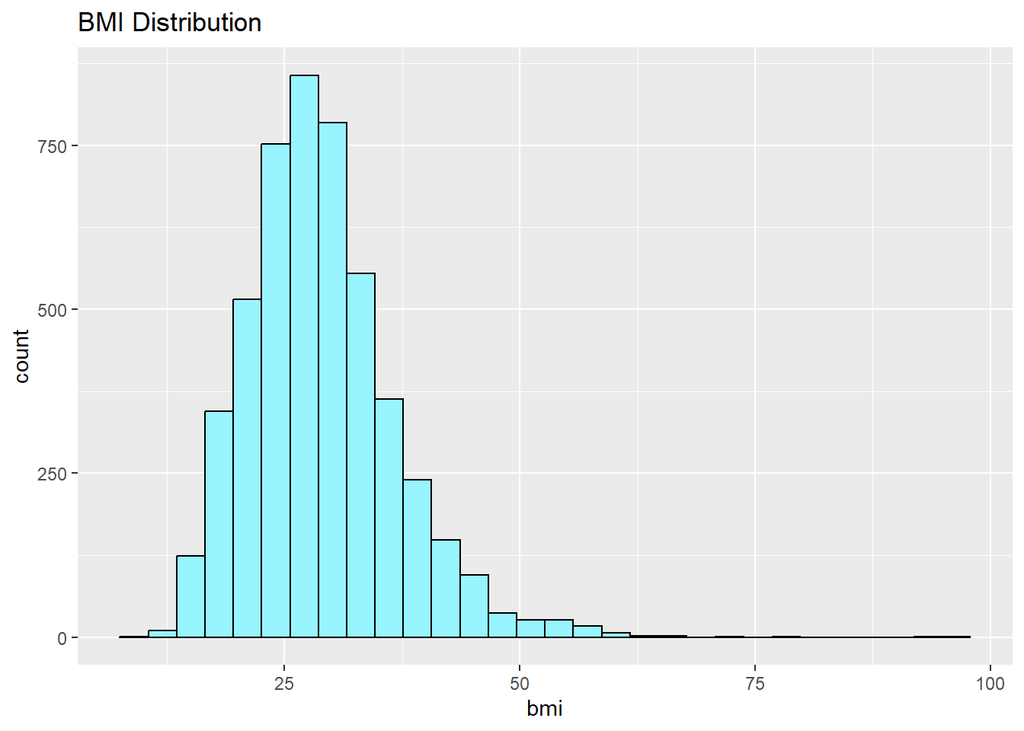

```r
ggplot(data, aes(x=bmi)) +
  geom_histogram(color="black", fill="cadetblue1")+
  labs(title = "BMI Distribution")
```

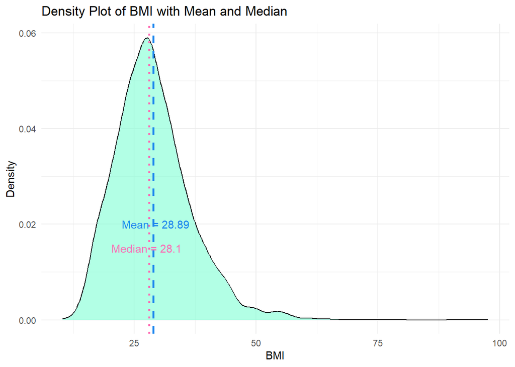

```r
bmi_mean <- mean(data$bmi)
bmi_median <- median(data$bmi)

# Density plot with a vertical line at the mean
ggplot(data, aes(x = data$bmi)) +
  geom_density(fill = "aquamarine1", alpha = 0.6) +
  geom_vline(aes(xintercept = bmi_mean), color = "dodgerblue2", linetype = "dashed", size = 1) +
  geom_vline(aes(xintercept = bmi_median), color = "hotpink1", linetype = "dotted", size = 1) +
  labs(title = "Density Plot of BMI with Mean and Median", x = "BMI", y = "Density") +
  annotate("text", x = bmi_mean + 0.5, y = 0.02, label = paste("Mean =", round(bmi_mean, 2)), color = "dodgerblue2") +
  annotate("text", x = bmi_median - 0.5, y = 0.015, label = paste("Median =", round(bmi_median, 2)), color = "hotpink1") +
  theme_minimal()
```

```r
skewness(data$bmi)
```

```
## [1] 1.054695
```

```r
kurtosis(data$bmi)
```

```
## [1] 3.355423
```

The values of the shape tell us that this is not a normal distribution. There’s a lot ot people in the center of the data but the quantity of people with a extremely high BMI that change the weigh of the tail in the distribution.

To see if the outliers are correctly in the heavier side we can check the boxplot of the *bmi*

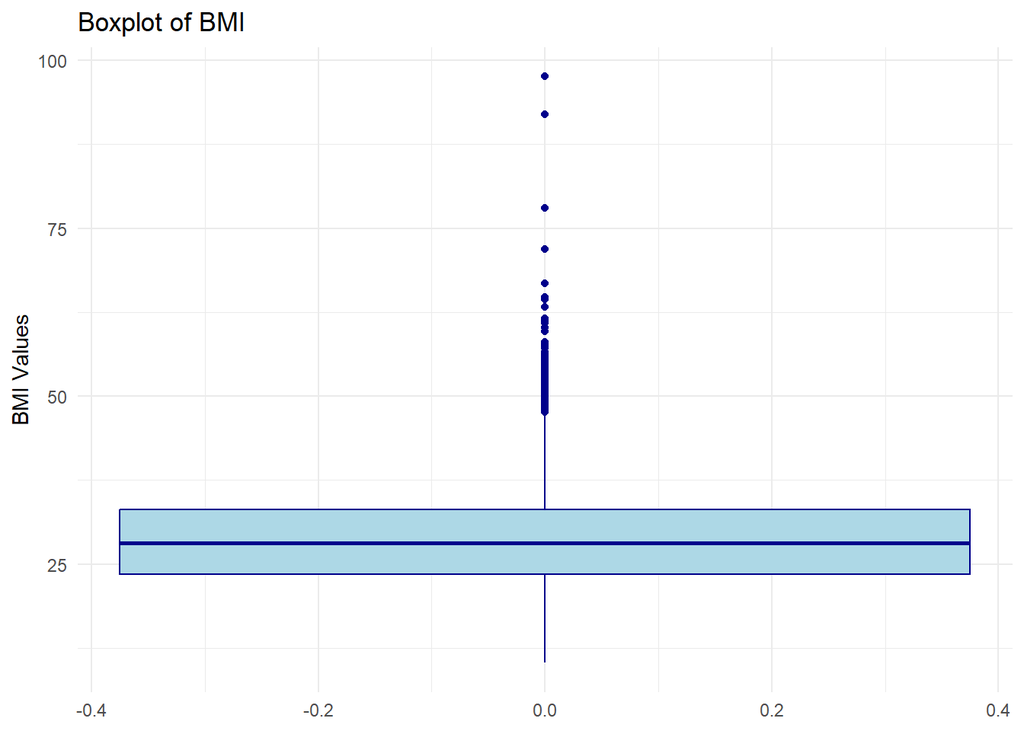

```r
ggplot(data, aes(y = data$bmi)) +
  geom_boxplot(fill = "lightblue", color = "darkblue") + # Change box and border color
  labs(title = "Boxplot of BMI", y = "BMI Values") + # Custom title and labels
  theme_minimal()
```

As you can see with the boxplot we can make sure that the *bmi* data have outliers within the largest values. The problem with this data is that we can not be sure if this is a mistake in the part of measure or maybe exist people with those values.

#### BMI with gender

```r
data_sub_bmi_gender= data %>% group_by(gender,stroke) %>% summarise(mean = mean(bmi))
print(data_sub_bmi_gender)
```

```
## # A tibble: 5 × 3
## # Groups:   gender [3]
##   gender stroke  mean
##   <fct>  <fct>  <dbl>
## 1 Female 0       29.0
## 2 Female 1       30.2
## 3 Male   0       28.5
## 4 Male   1       30.8
## 5 Other  0       22.4
```

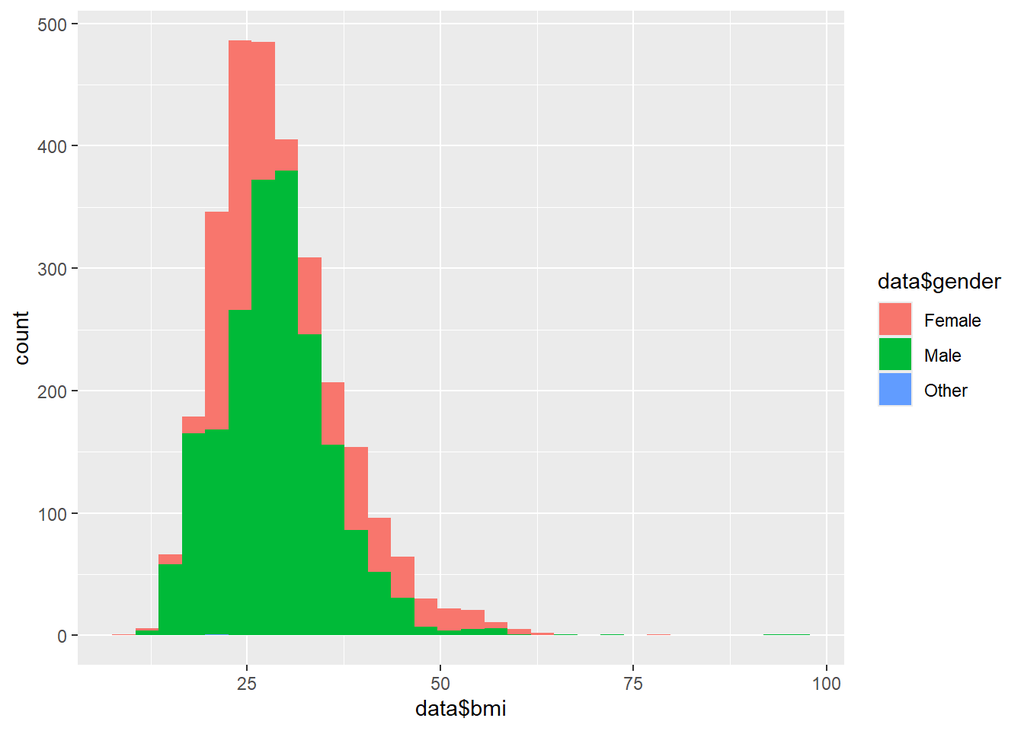

```r
ggplot(data, aes(x = data$bmi, fill = data$gender)) +
  geom_histogram(position = "identity", bins = 30)
```

#### BMI with hypertension

```r
data_sub_bmi_hyper= data %>% group_by(hypertension,stroke) %>% summarise(mean = mean(bmi))
print(data_sub_bmi_hyper)
```

```
## # A tibble: 4 × 3
## # Groups:   hypertension [2]
##   hypertension stroke  mean
##   <fct>        <fct>  <dbl>
## 1 0            0       28.4
## 2 0            1       30.3
## 3 1            0       33.4
## 4 1            1       30.9
```

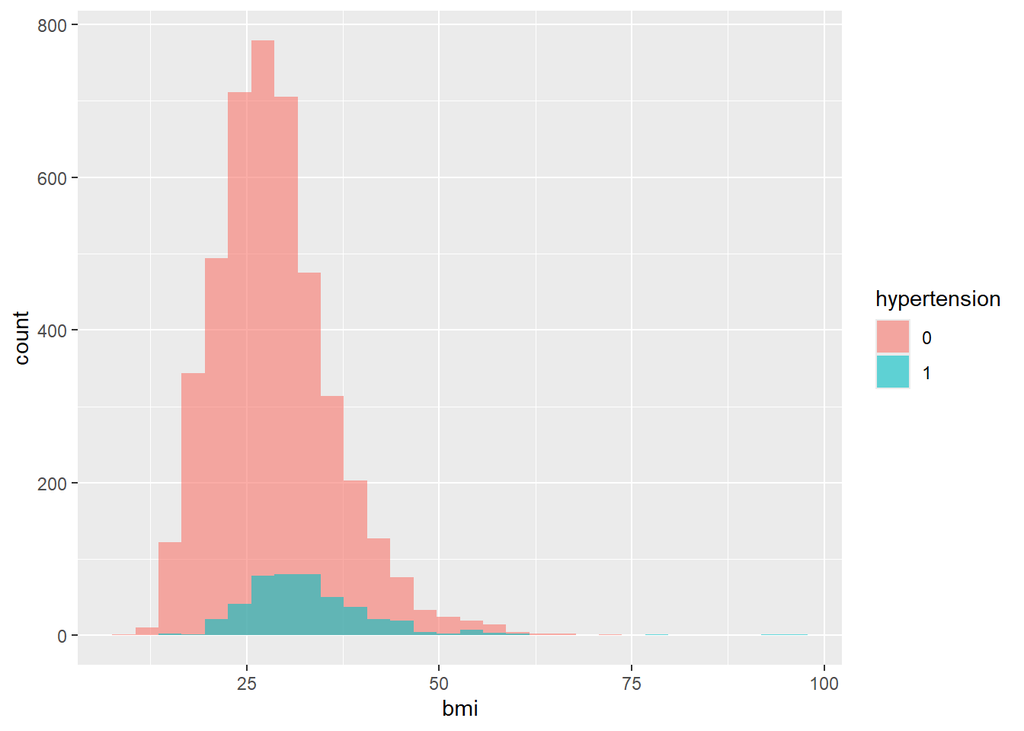

```r
ggplot(data, aes(x = bmi, fill = hypertension)) +
  geom_histogram(alpha = 0.6, position = "identity", bins = 30)
```

#### BMI with stroke

```r
data_sub_bmi_catw= data %>% group_by(cat_weight,stroke) %>% summarise(mean = mean(bmi))
print(data_sub_bmi_catw)
```

```
## # A tibble: 10 × 3
## # Groups:   cat_weight [5]
##    cat_weight      stroke  mean
##    <fct>           <fct>  <dbl>
##  1 Underweight     0       16.7
##  2 Underweight     1       16.9
##  3 Normal          0       22.2
##  4 Normal          1       22.6
##  5 Overweight      0       27.5
##  6 Overweight      1       27.6
##  7 Obese           0       32.2
##  8 Obese           1       32.1
##  9 Extremely Obese 0       41.1
## 10 Extremely Obese 1       40.3
```

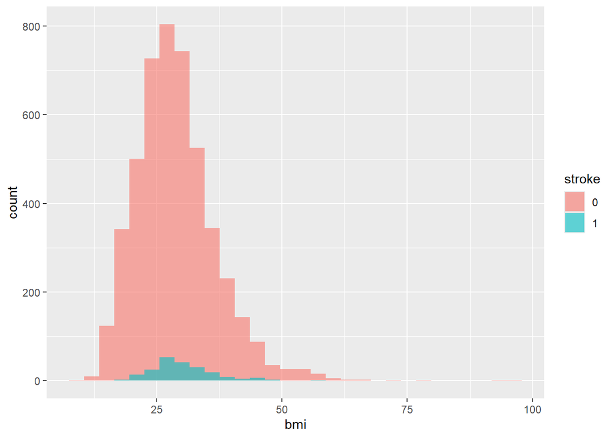

```r
ggplot(data, aes(x = bmi, fill = stroke)) +
  geom_histogram(alpha = 0.6, position = "identity", bins = 30)
```

### Glucose levels

#### Glucose levels with gender

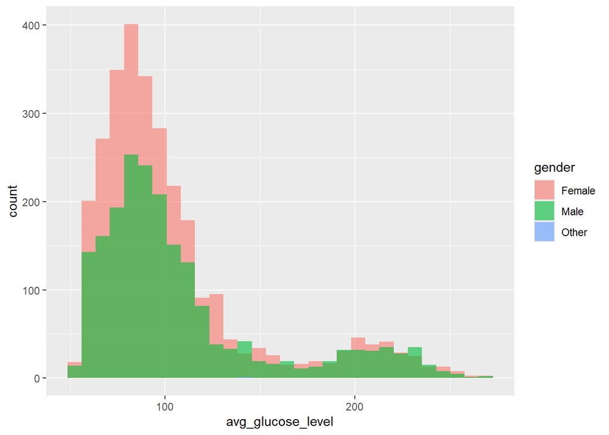

```r
ggplot(data, aes(x = avg_glucose_level, fill = gender)) +
  geom_histogram(alpha = 0.6, position = "identity", bins = 30)
```

#### Glucose levels with hypertension

```r
data_sub_glu_hyp= data %>% group_by(hypertension,stroke) %>% summarise(mean = mean(avg_glucose_level))
print(data_sub_glu_hyp)
```

```
## # A tibble: 4 × 3
## # Groups:   hypertension [2]
##   hypertension stroke  mean
##   <fct>        <fct>  <dbl>
## 1 0            0       102.
## 2 0            1       130.
## 3 1            0       128.
## 4 1            1       146.
```

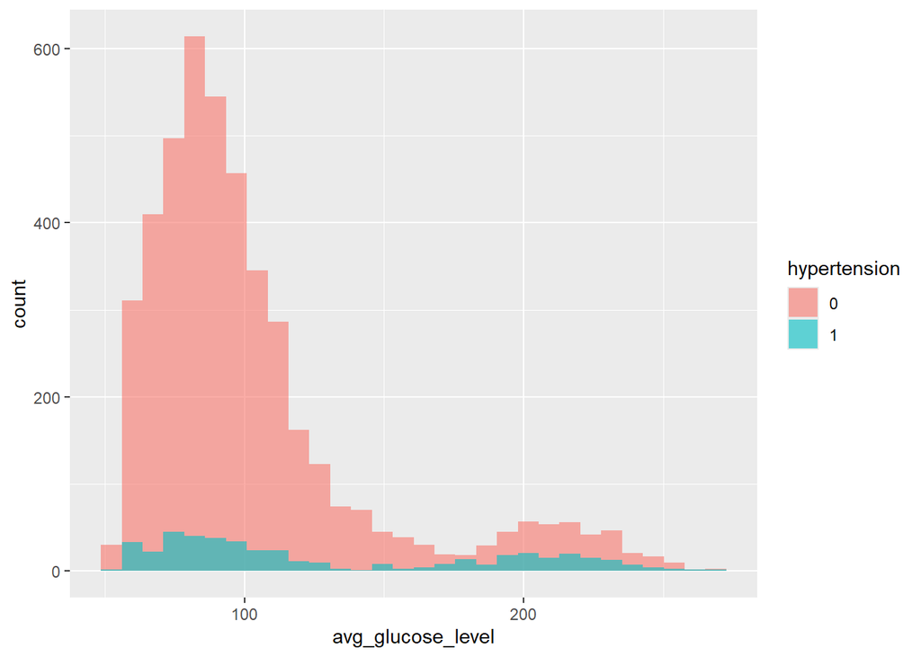

```r
ggplot(data, aes(x = avg_glucose_level, fill = hypertension)) +
  geom_histogram(alpha = 0.6, position = "identity", bins = 30)
```

#### Glucose levels with stroke

```r
data_sub_glu= data %>% group_by(stroke) %>% summarise(mean = mean(avg_glucose_level))
print(data_sub_glu)
```

```
## # A tibble: 2 × 2
##   stroke  mean
##   <fct>  <dbl>
## 1 0       104.
## 2 1       135.
```

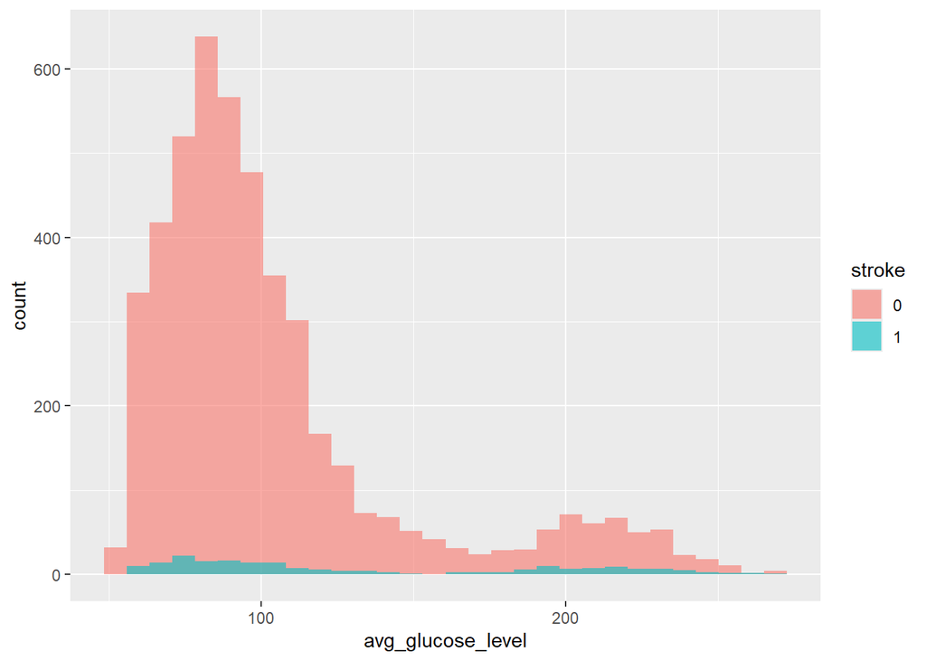

```r
ggplot(data, aes(x = avg_glucose_level, fill = stroke)) +
  geom_histogram(alpha = 0.6, position = "identity", bins = 30)
```

### Age

#### Age levels with gender

```r
data_sub_age_gender= data %>% group_by(gender,stroke) %>% summarise(mean = mean(age))
print(data_sub_age_gender)
```

```
## # A tibble: 5 × 3
## # Groups:   gender [3]
##   gender stroke  mean
##   <fct>  <fct>  <dbl>
## 1 Female 0       42.4
## 2 Female 1       67.2
## 3 Male   0       40.8
## 4 Male   1       68.3
## 5 Other  0       26
```

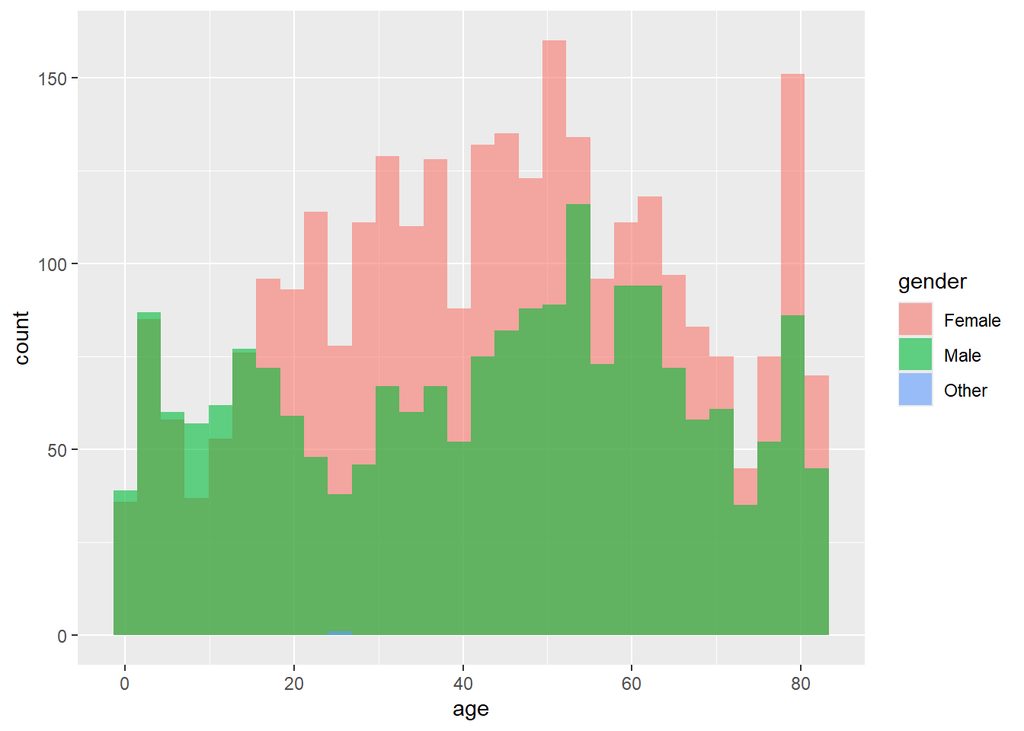

```r
ggplot(data, aes(x = age, fill = gender)) +
  geom_histogram(alpha = 0.6, position = "identity", bins = 30)
```

#### Age levels with hypertension

```r
data_sub_age_hyp= data %>% group_by(hypertension,stroke) %>% summarise(mean = mean(age))
print(data_sub_age_hyp)
```

```
## # A tibble: 4 × 3
## # Groups:   hypertension [2]
##   hypertension stroke  mean
##   <fct>        <fct>  <dbl>
## 1 0            0       40.0
## 2 0            1       67.0
## 3 1            0       61.2
## 4 1            1       69.6
```

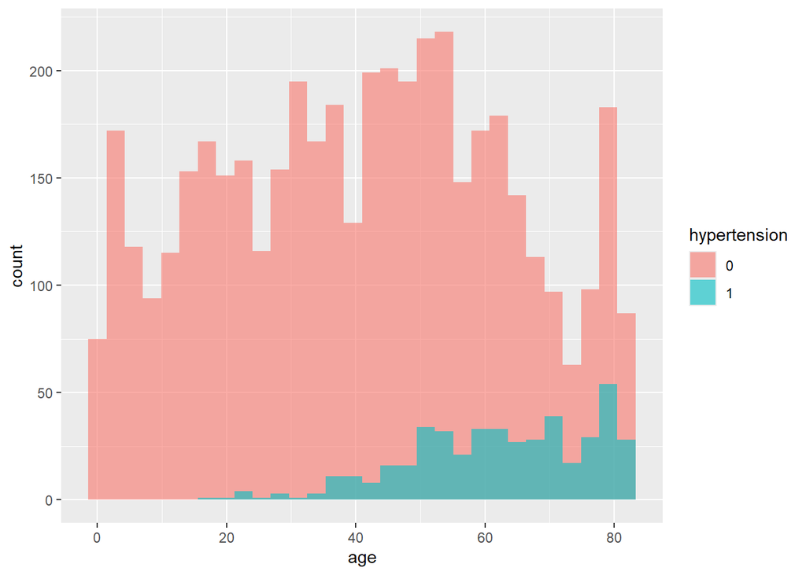

```r
ggplot(data, aes(x = age, fill = hypertension)) +
  geom_histogram(alpha = 0.6, position = "identity", bins = 30)
```

```r
data_sub_age= data %>% group_by(stroke) %>% summarise(mean = mean(age))
print(data_sub_age)
```

```
## # A tibble: 2 × 2
##   stroke  mean
##   <fct>  <dbl>
## 1 0       41.8
## 2 1       67.7
```

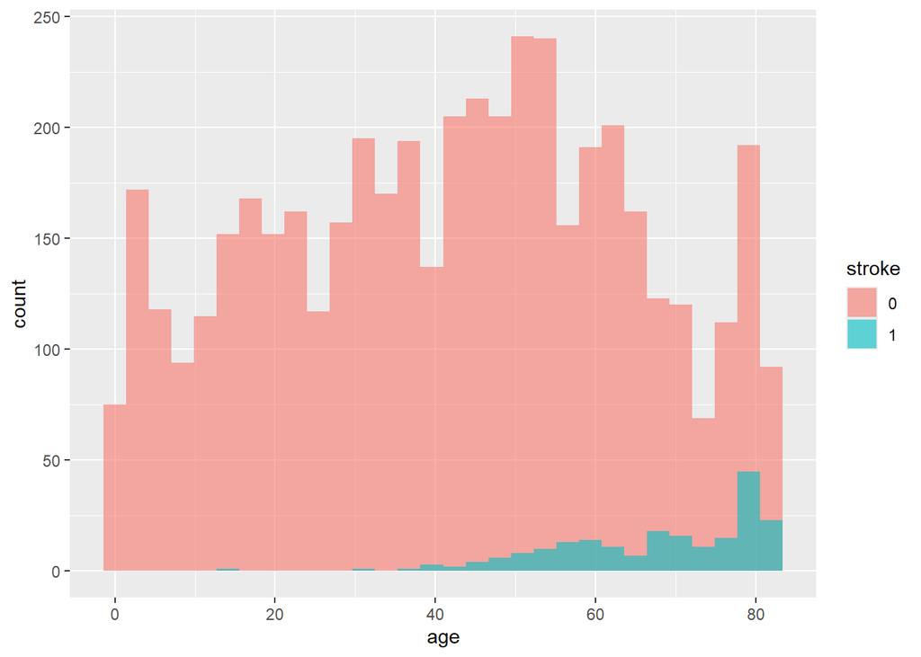

```r
ggplot(data, aes(x = age, fill = stroke)) +
  geom_histogram(alpha = 0.6, position = "identity", bins = 30)
```